# Lab 5: Insurance Costs

Author

Sydney Thompson

Github Link: https://github.com/orsydney003/GSB_S544/tree/main/Lab5

# 1. Part One: Data Exploration

The dataset we will study for this assignment contains information about health insurance costs for individuals with no dependents (children) in the United States. The information contained in the data is:

Age of primary beneficiary

Gender of primary beneficiary (only female, male recorded)

Body mass index, providing an understanding of body, weights that are relatively high or low relative to height, objective index of body weight (kg / m ^ 2) using the ratio of height to weight, ideally 18.5 to 24.9

Whether the beneficiary smokes

The beneficiary’s residential area in the US, northeast, southeast, southwest, northwest.

Individual medical costs billed by health insurance

You can find this data at: https://www.dropbox.com/s/bocjjyo1ehr5auz/insurance_costs_1.csv?dl=1

## 1. Read in the dataset, and display some summaries of the data.

```python
# importing dataset
import pandas as pd
insurance_data = pd.read_csv("https://www.dropbox.com/s/bocjjyo1ehr5auz/insurance_costs_1.csv?dl=1")
insurance_data
```

|  | age | sex | bmi | smoker | region | charges |
| --- | --- | --- | --- | --- | --- | --- |
| 0 | 19 | female | 27.900 | yes | southwest | 16884.92400 |
| 1 | 33 | male | 22.705 | no | northwest | 21984.47061 |
| 2 | 32 | male | 28.880 | no | northwest | 3866.85520 |
| 3 | 31 | female | 25.740 | no | southeast | 3756.62160 |
| 4 | 60 | female | 25.840 | no | northwest | 28923.13692 |
| ... | ... | ... | ... | ... | ... | ... |
| 426 | 23 | female | 33.400 | no | southwest | 10795.93733 |
| 427 | 18 | female | 31.920 | no | northeast | 2205.98080 |
| 428 | 18 | female | 36.850 | no | southeast | 1629.83350 |
| 429 | 21 | female | 25.800 | no | southwest | 2007.94500 |
| 430 | 61 | female | 29.070 | yes | northwest | 29141.36030 |

431 rows × 6 columns

```python
# shows information about the DataFrame
insurance_data.info()
```

```
<class 'pandas.core.frame.DataFrame'>
RangeIndex: 431 entries, 0 to 430
Data columns (total 6 columns):
 #   Column   Non-Null Count  Dtype
---  ------   --------------  -----
 0   age      431 non-null    int64
 1   sex      431 non-null    object
 2   bmi      431 non-null    float64
 3   smoker   431 non-null    object
 4   region   431 non-null    object
 5   charges  431 non-null    float64
dtypes: float64(2), int64(1), object(3)
memory usage: 20.3+ KB
```

```python
# provides descriptive stats summaries
insurance_data.describe()
```

|  | age | bmi | charges |
| --- | --- | --- | --- |
| count | 431.000000 | 431.000000 | 431.000000 |
| mean | 37.960557 | 30.768898 | 12297.098118 |
| std | 16.363909 | 6.111362 | 11876.527128 |
| min | 18.000000 | 15.960000 | 1131.506600 |
| 25% | 22.000000 | 26.357500 | 2710.444575 |
| 50% | 34.000000 | 30.590000 | 9866.304850 |
| 75% | 55.000000 | 35.272500 | 14510.872600 |
| max | 64.000000 | 49.060000 | 55135.402090 |

```python
# checking for missing values in each column
insurance_data.isnull().sum()
```

```
age        0
sex        0
bmi        0
smoker     0
region     0
charges    0
dtype: int64
```

```python
# number of unique values in each column
insurance_data.nunique()
```

```
age         47
sex          2
bmi        305
smoker       2
region       4
charges    430
dtype: int64
```

## 2. Fix any concerns you have about the data.

Because of the summaries I provided above, I don’t think I need to fix anything. I don’t see any missing or invalid values.

I will dummify the categorical variables and visualize a couple distributions to check and see if there are any extreme outliers.

```python
pd.get_dummies(insurance_data)
```

|  | age | bmi | charges | sex_female | sex_male | smoker_no | smoker_yes | region_northeast | region_northwest | region_southeast | region_southwest |
| --- | --- | --- | --- | --- | --- | --- | --- | --- | --- | --- | --- |
| 0 | 19 | 27.900 | 16884.92400 | True | False | False | True | False | False | False | True |
| 1 | 33 | 22.705 | 21984.47061 | False | True | True | False | False | True | False | False |
| 2 | 32 | 28.880 | 3866.85520 | False | True | True | False | False | True | False | False |
| 3 | 31 | 25.740 | 3756.62160 | True | False | True | False | False | False | True | False |
| 4 | 60 | 25.840 | 28923.13692 | True | False | True | False | False | True | False | False |
| ... | ... | ... | ... | ... | ... | ... | ... | ... | ... | ... | ... |
| 426 | 23 | 33.400 | 10795.93733 | True | False | True | False | False | False | False | True |
| 427 | 18 | 31.920 | 2205.98080 | True | False | True | False | True | False | False | False |
| 428 | 18 | 36.850 | 1629.83350 | True | False | True | False | False | False | True | False |
| 429 | 21 | 25.800 | 2007.94500 | True | False | True | False | False | False | False | True |
| 430 | 61 | 29.070 | 29141.36030 | True | False | False | True | False | True | False | False |

431 rows × 11 columns

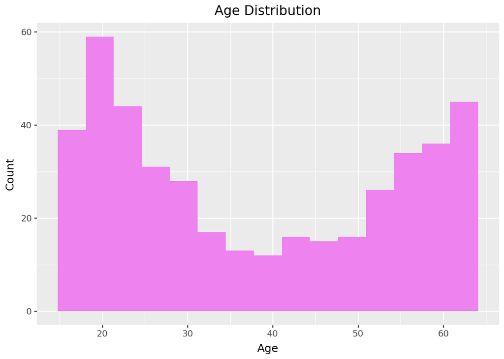

```python
from plotnine import *
# histogram of age
ggplot(insurance_data, aes(x = 'age')) + geom_histogram(bins = 15, fill = "violet") + labs(title = "Age Distribution", x = "Age", y = "Count")
```

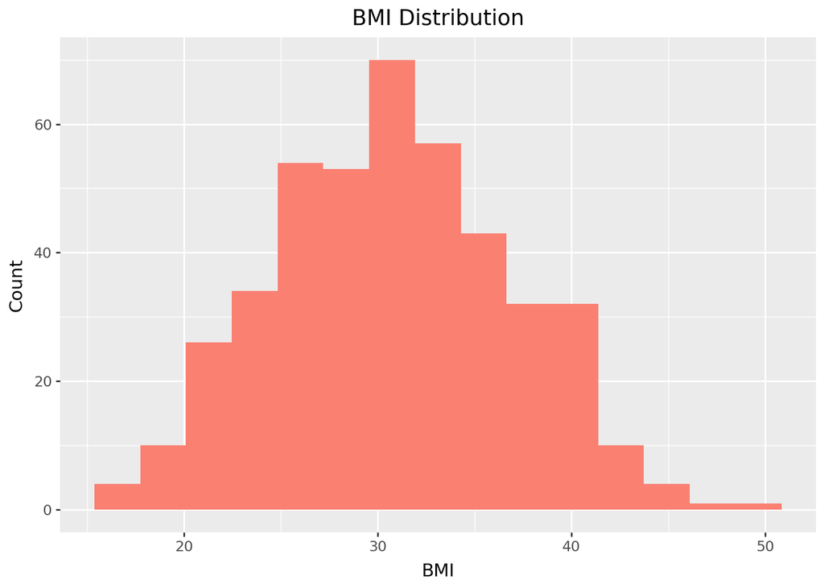

```python
# histogram of bmi
ggplot(insurance_data, aes(x='bmi')) + geom_histogram(bins=15, fill="salmon") + labs(title='BMI Distribution', x='BMI', y='Count')
```

## 3. Make up to three plots comparing the response variable (charges) to one of the predictor variables. Briefly discuss each plot.

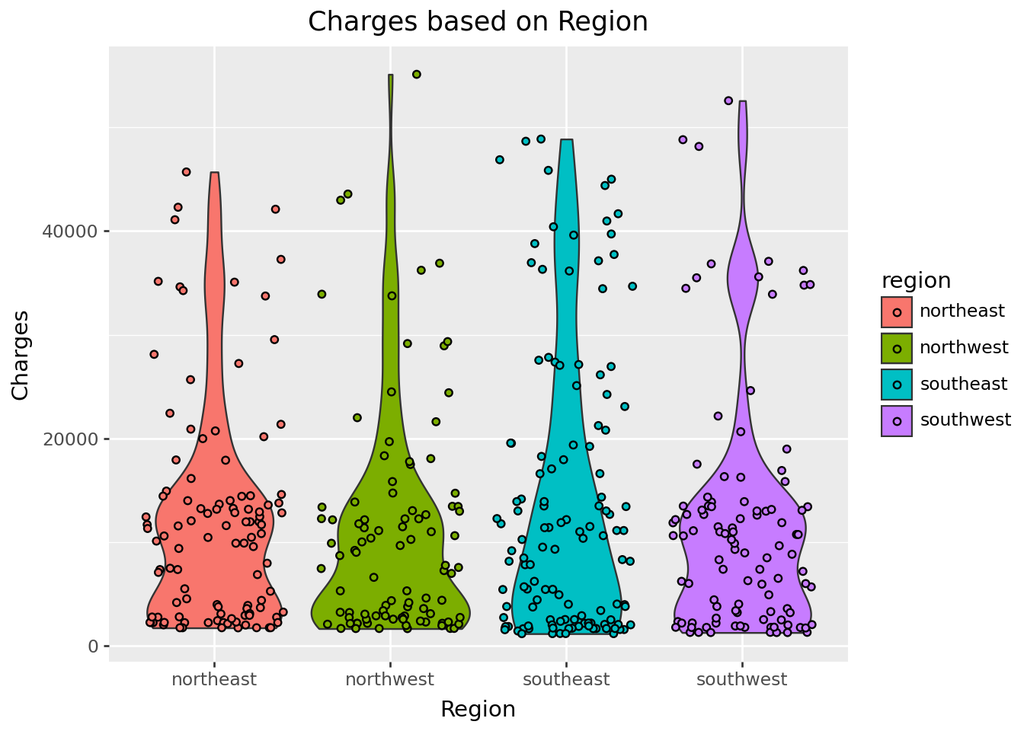

```python
# charges based on region

ggplot(insurance_data, aes(x='region', y='charges', fill='region')) + geom_violin() + geom_jitter() + labs(title = "Charges based on Region", x = "Region", y = "Charges")
```

Insurance charges vary across different US regions, but it seems that the northwest region has the widest spread. This plot shows that there are regional differences based on lifestyle and cost of living. The northeast region has the lowest spread, and it seems it has more consistent costs.

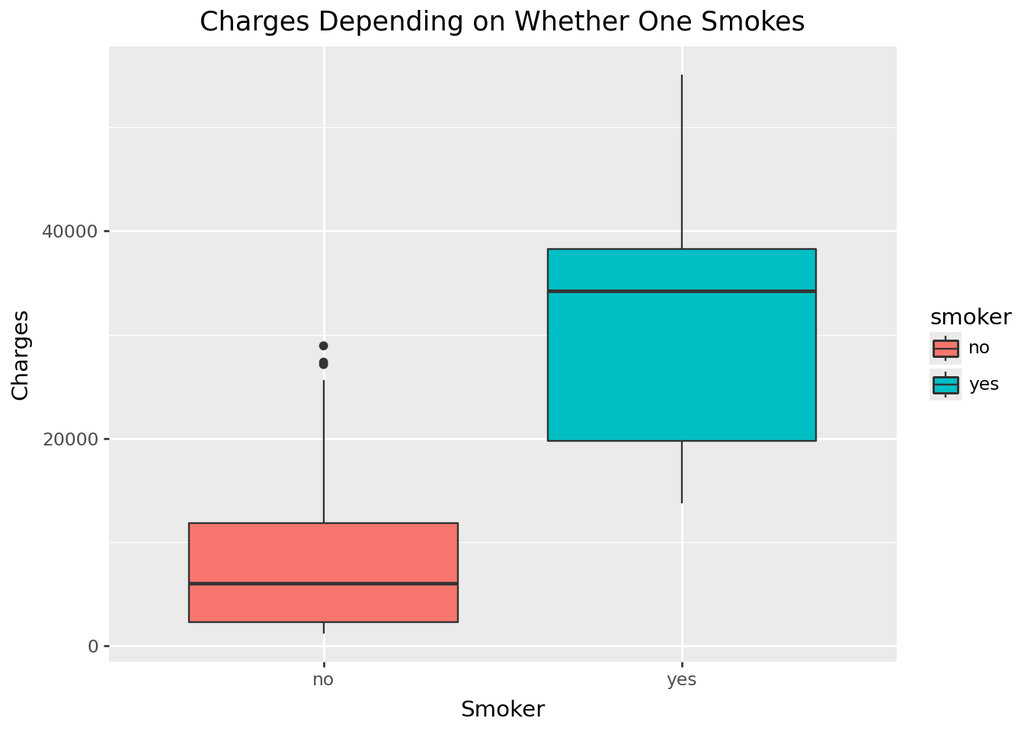

```python
# charges by smoker

ggplot(insurance_data, aes(x='smoker', y='charges', fill='smoker')) + geom_boxplot() + labs(title = "Charges Depending on Whether One Smokes", x = "Smoker", y = "Charges")
```

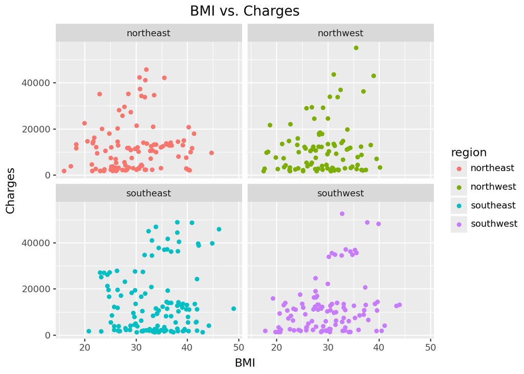

```python
# bmi vs. charges using facet_wrap()

ggplot(insurance_data, aes(x='bmi', y='charges', color = 'region')) + geom_point() + facet_wrap('~region') + labs(title = "BMI vs. Charges", x = "BMI", y = "Charges")
```

Charges tend to rise if a person has a higher BMI. This is evident in all US regions; I see similar patterns between all four of these regions. If someone has an extremely high BMI, this means they will probably have higher medical charges.

# 2. Part Two: Simple Linear Models

## 1. Construct a simple linear model to predict the insurance charges from the beneficiary’s age. Discuss the model fit, and interpret the coefficient estimates.

```python
from sklearn.linear_model import LinearRegression
```

```python
charges_model = LinearRegression()

charges_model.fit(
  X = insurance_data[["age"]],
  y = insurance_data["charges"]
)
```

```
LinearRegression()
```

```python
charges_model.coef_
# output: 228.79904937
```

```
array([228.79904937])
```

```python
charges_model.intercept_
# output: 3611.7587985071077
```

```
np.float64(3611.7587985071077)
```

```python
from sklearn.metrics import mean_squared_error, r2_score

# second model with age

age_X = pd.get_dummies(insurance_data[["age"]])
prd_age = charges_model.predict(age_X)
mse_age1 = mean_squared_error(insurance_data["charges"], prd_age)
r2_age = r2_score(insurance_data["charges"], prd_age)

mse_age1
# output: 126739267.91026388
```

```
126739267.91026388
```

```python
r2_age
# output: 0.09938105452062707
```

```
0.09938105452062707
```

The coefficient is looking at how much insurance charges increase as you get older each year. For every year you get older, your predicted insurance costs increase by approximately $228.80.

The intercept is your estimated charge when an individual is 0. In this case, it’s $3611.76. However, this doesn’t make any sense in this example.

## 2. Make a model that also incorporates the variable sex. Report your results.

```python
charges_model_new = LinearRegression()

charges_model_new.fit(
  X = pd.get_dummies(insurance_data[["age", "sex"]]),
  y = insurance_data["charges"]
)
```

```
LinearRegression()
```

```python
charges_model_new.coef_
# output: array([ 228.42586236, -324.91629499,  324.91629499])
```

```
array([ 228.42586236, -324.91629499,  324.91629499])
```

```python
charges_model_new.intercept_
# output: 3640.2486415205276
```

```
np.float64(3640.2486415205276)
```

The intercept in this example is $3640.25 when age = 0. Again, this doesn’t make sense in this context.

## 3. Now make a model that does not include sex, but does include smoker. Report your results.

```python
charges_model_smoker = LinearRegression()

charges_model_smoker.fit(
  X = pd.get_dummies(insurance_data[["age", "smoker"]]),
  y = insurance_data["charges"]
)
```

```
LinearRegression()
```

```python
charges_model_smoker.coef_
# output: array([   253.14535549, -12024.43371898,  12024.43371898])
```

```
array([   253.14535549, -12024.43371898,  12024.43371898])
```

```python
charges_model_smoker.intercept_
# output: 9857.581423601509
```

```
np.float64(9857.581423601509)
```

The intercept is $9857.58 when age = 0. Again, it doesn’t make sense in this context because you need to be at least 18 years old to have insurance costs.

## 4. Which model (Q2 or Q3) do you think better fits the data? Justify your answer by calculating the MSE for each model, and also by comparing R-squared values.

```python
from sklearn.metrics import mean_squared_error, r2_score

# second model with sex

sex_X = pd.get_dummies(insurance_data[["age", "sex"]])
prd_sex = charges_model_new.predict(sex_X)
mse_sex = mean_squared_error(insurance_data["charges"], prd_sex)
r2_sex = r2_score(insurance_data["charges"], prd_sex)

mse_sex
# output: 126633939.67937087
```

```
126633939.67937087
```

```python
r2_sex
# output: 0.10012952499706396
```

```
0.10012952499706396
```

```python
# third model with smoker

smoker_X = pd.get_dummies(insurance_data[["age", "smoker"]])
prd_smoker = charges_model_smoker.predict(smoker_X)
mse_smoker = mean_squared_error(insurance_data["charges"], prd_smoker)
r2_smoker = r2_score(insurance_data["charges"], prd_smoker)

mse_smoker
# output: 33719831.46524372
```

```
33719831.46524372
```

```python
r2_smoker
# output: 0.7603842948069405
```

```
0.7603842948069405
```

Q3 (the Age + Smoker model) fits the data better. Whether a person smokes affects how much their insurance costs. This model also has a lower MSE and higher R-squared than Q2 (Age + Sex). Smoking status is a big factor in undering the variation of medical costs in this dataset.

# Part 3: Multiple Linear Models

Now let’s consider including multiple quantitative predictors.

## 1. Fit a model that uses age and bmi as predictors. (Do not include an interaction term, age*bmi, between these two.) Report your results. How does the MSE compare to the model in Part Two Q1? How does the R-squared compare?

```python
from sklearn.preprocessing import PolynomialFeatures
import numpy as np

age_bmi_model = LinearRegression()

age_bmi_model.fit(
  X = insurance_data[["age", "bmi"]],
  y = insurance_data["charges"]
)
```

```
LinearRegression()
```

```python
age_bmi_model.coef_
# output: array([216.29721472, 283.20380126])
```

```
array([216.29721472, 283.20380126])
```

```python
age_bmi_model.intercept_
# output: -4627.533445708479
```

```
np.float64(-4627.533445708479)
```

```python
X_age_bmi = insurance_data[["age", "bmi"]]

prd_age_bmi = age_bmi_model.predict(X_age_bmi)

mse_age_bmi = mean_squared_error(insurance_data["charges"], prd_age_bmi)

r2_age_bmi = r2_score(insurance_data["charges"], prd_age_bmi)

mse_age_bmi
# output: 123792439.58129103
```

```
123792439.58129103
```

```python
r2_age_bmi
# output: 0.12032144234129338
```

```
0.12032144234129338
```

Compared to P2 Q1, the MSE is the lowest (123792439.58129103 vs. 126739267.91026388) compared to P2 Q1. However, the R-squared is the highest (0.09938105452062707 vs. 0.12032144234129338).

Also, with BMI and age included in the model, the intercept and coefficient both decrease.

## 2. Perhaps the relationships are not linear. Fit a model that uses age and age^2 as predictors. How do the MSE and R-squared compare to the model in P2 Q1?

```python
insurance_data["age_quad"] = insurance_data["age"] ** 2

age_quad_model = LinearRegression()

age_quad_model.fit(
  X = insurance_data[["age", "age_quad"]],
  y = insurance_data["charges"]
)
```

```
LinearRegression()
```

```python
age_quad_model.coef_
# output: array([308.42816984,  -1.00150889])
```

```
array([308.42816984,  -1.00150889])
```

```python
age_quad_model.intercept_
# output: $2299.7305687267035
```

```
np.float64(2299.7305687267035)
```

```python
X_age2 = insurance_data[["age", "age_quad"]]

prd_age_quad = age_quad_model.predict(X_age2)

mse_age_quad = mean_squared_error(insurance_data["charges"], prd_age_quad)

r2_age_quad = r2_score(insurance_data["charges"], prd_age_quad)

mse_age_quad
# output: 126710293.80956802
```

```
126710293.80956802
```

```python
r2_age_quad
# output: 0.09958694669946933
```

```
0.09958694669946933
```

Compared to P2 Q1, the MSE is lower (126710293.80956802 vs. 126739267.91026388). However, the R-squared is slightly higher (0.09938105452062707 vs. 0.09958694669946933). I think this does a better job at showing how costs rise for older people.

Also, when looking at the quadratic model of age, the coefficient increases and intercept decreases when compared to P2 Q1.

## 3. Fit a polynomial model of degree 4. How do the MSE and R-squared compare to the model in P2 Q1?

```python
# creating other variables for degree 4 model
insurance_data["age2"] = insurance_data["age"] ** 2
insurance_data["age3"] = insurance_data["age"] ** 3
insurance_data["age4"] = insurance_data["age"] ** 4

age_poly_model = LinearRegression()

age_poly_model.fit(
  X = insurance_data[["age", "age2", "age3", "age4"]],
  y = insurance_data["charges"]
)
```

```
LinearRegression()
```

```python
age_poly_model.coef_
# output: array([-7.94841022e+03,  3.58110163e+02, -6.47905090e+00,  4.12933982e-02])
```

```
array([-7.94841022e+03,  3.58110163e+02, -6.47905090e+00,  4.12933982e-02])
```

```python
age_poly_model.intercept_
# output: 68637.89783086351
```

```
np.float64(68637.89783086351)
```

```python
X_age4 = insurance_data[["age", "age2", "age3", "age4"]]

prd_age_poly = age_poly_model.predict(X_age4)

mse_age_poly = mean_squared_error(insurance_data["charges"], prd_age_poly)

r2_age_poly = r2_score(insurance_data["charges"], prd_age_poly)

mse_age_poly
# output: 125550389.64569819
```

```
125550389.64569819
```

```python
r2_age_poly
# output: 0.10782931453183842
```

```
0.10782931453183842
```

Compared to P2 Q1, the MSE is lower (125550389.64569819 vs. 126739267.91026388) again. However, the R-squared is higher (0.09938105452062707 vs. 0.10782931453183842).

Also, when looking at the quartic model of age, the coefficient increases and decreases. The intercept increases substantially when compared to P2 Q1.

## 4. Fit a polynomial model of degree 12. How do the MSE and R-squared compare to the model in P2 Q1?

```python
# other degrees for computing deg12 model
insurance_data["age5"] = insurance_data["age"] ** 5
insurance_data["age6"] = insurance_data["age"] ** 6
insurance_data["age7"] = insurance_data["age"] ** 7
insurance_data["age8"] = insurance_data["age"] ** 8
insurance_data["age9"] = insurance_data["age"] ** 9
insurance_data["age10"] = insurance_data["age"] ** 10
insurance_data["age11"] = insurance_data["age"] ** 11
insurance_data["age12"] = insurance_data["age"] ** 12

age_deg12_model = LinearRegression()

age_deg12_model.fit(
  X = insurance_data[["age", "age2", "age3", "age4","age5", "age6", "age7", "age8", "age9", "age10", "age11", "age12"]],
  y = insurance_data["charges"]
)
```

```
LinearRegression()
```

```python
age_deg12_model.coef_
# output: array([ 3.04916799e-12,  5.89822181e-11,  3.44179451e-09,  7.56353233e-08,  1.26243824e-06,  1.25112263e-05, -2.08396121e-08, -1.85914368e-08, 4.09818469e-10, -2.52044345e-12, -1.01992411e-17,  1.42766006e-16])
```

```
array([ 3.04916799e-12,  5.89822181e-11,  3.44179451e-09,  7.56353233e-08,
        1.26243824e-06,  1.25112263e-05, -2.08396121e-08, -1.85914368e-08,
        4.09818469e-10, -2.52044345e-12, -1.01992411e-17,  1.42766006e-16])
```

```python
age_deg12_model.intercept_
# output: 7452.282356268564
```

```
np.float64(7452.282356268564)
```

```python
X_age12 = insurance_data[["age", "age2", "age3", "age4","age5", "age6", "age7", "age8", "age9", "age10", "age11", "age12"]]

prd_age12 = age_deg12_model.predict(X_age12)

mse_age12 = mean_squared_error(insurance_data["charges"], prd_age12)

r2_age12 = r2_score(insurance_data["charges"], prd_age12)

mse_age12
# output: 125373053.69366246
```

```
125373053.69366246
```

```python
r2_age12
# output: 0.10908947739021224
```

```
0.10908947739021224
```

Compared to P2 Q1, this MSE is lower than in P2 Q1 (125373053.69366246 vs. 126739267.91026388). In this case, this R-squared value is higher (0.09938105452062707 vs. 0.10908947739021224). With a model this complex, this may be overfitting the data.

Also, when looking at the degree 12 model, the coefficient increases and decreases. The intercept increases when compared to P2 Q1.

## 5. According to the MSE and R-squared, which is the best model? Do you agree that this is indeed the “best” model? Why or why not?

```python
summary = pd.DataFrame({
    "Model": [
        "Age + BMI (linear)",
        "Age + Age² (quadratic)",
        "Age (degree 4)",
        "Age (degree 12)"
    ],
    "MSE": [mse_age_bmi, mse_age_quad, mse_age_poly, mse_age12],
    "R²": [r2_age_bmi, r2_age_quad, r2_age_poly, r2_age12]
})

summary
```

|  | Model | MSE | R² |
| --- | --- | --- | --- |
| 0 | Age + BMI (linear) | 1.237924e+08 | 0.120321 |
| 1 | Age + Age² (quadratic) | 1.267103e+08 | 0.099587 |
| 2 | Age (degree 4) | 1.255504e+08 | 0.107829 |
| 3 | Age (degree 12) | 1.253731e+08 | 0.109089 |

According to the MSE and R-squared, the linear model looks the best. This is based on its low MSE and high R-squared value. However, I do not agree that this is indeed the “best” model because it’s underfitting the model. Instead, I think the quartic model would be a better fit because it might better capture this relationship between age and charges.

## 6. Plot the predictions from your model in Q4 as a line plot on top of the scatterplot of your original data.

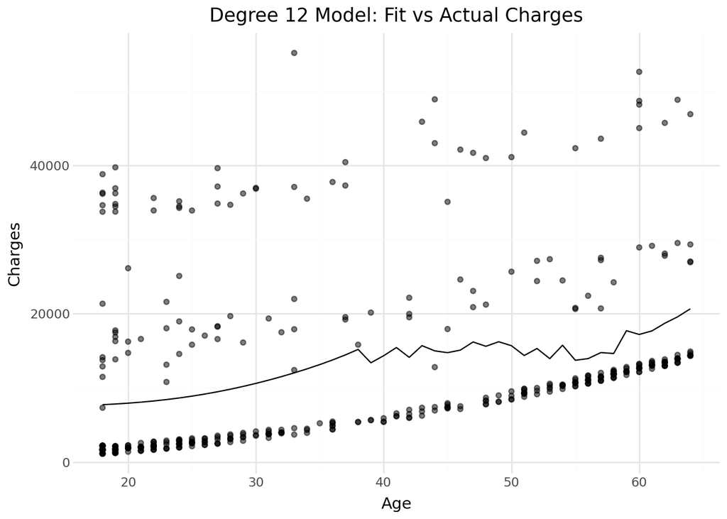

```python
# degree 12 polynomial fit on age

X_age12 = insurance_data[["age", "age2", "age3", "age4","age5", "age6", "age7", "age8", "age9", "age10", "age11", "age12"]]

prd_age12 = age_deg12_model.predict(X_age12)

# for plotting
df_plot = insurance_data
df_plot["pred_age12"] = prd_age12
df_plot_sorted = df_plot.sort_values("age")

# Plot with plotnine
p = (
    ggplot(df_plot, aes(x = "age", y = "charges"))
    + geom_point(alpha=0.5)
    + geom_line(df_plot_sorted, aes(x = "age", y = "pred_age12"))
    + labs(
        title="Degree 12 Model: Fit vs Actual Charges",
        x="Age",
        y="Charges"
    )
    + theme_minimal()
)

p
```

# Part Four: New Data

Great news! We’ve managed to collect data about the insurance costs for a few more individuals. You can find the new dataset here: https://www.dropbox.com/s/sky86agc4s8c6qe/insurance_costs_2.csv?dl=1

Consider the following possible models:

Only age as a predictor.

age and bmi as a predictor.

age, bmi, and smoker as predictors (no interaction terms)

age, and bmi, with both quantitative variables having an interaction term with smoker (i.e. the formula ~ (age + bmi):smoker)

age, bmi, and smoker as predictors, with both quantitative variables having an interaction term with smoker (i.e. the formula ~ (age + bmi)*smoker)

```python
# importing new dataset
import pandas as pd
insurance_newdata = pd.read_csv("https://www.dropbox.com/s/sky86agc4s8c6qe/insurance_costs_2.csv?dl=1")
insurance_newdata
```

|  | age | sex | bmi | smoker | region | charges |
| --- | --- | --- | --- | --- | --- | --- |
| 0 | 23 | male | 34.400 | no | southwest | 1826.84300 |
| 1 | 56 | male | 40.300 | no | southwest | 10602.38500 |
| 2 | 18 | male | 34.100 | no | southeast | 1137.01100 |
| 3 | 63 | female | 23.085 | no | northeast | 14451.83515 |
| 4 | 63 | male | 28.310 | no | northwest | 13770.09790 |
| ... | ... | ... | ... | ... | ... | ... |
| 138 | 19 | male | 34.900 | yes | southwest | 34828.65400 |
| 139 | 45 | male | 30.360 | yes | southeast | 62592.87309 |
| 140 | 43 | male | 27.800 | yes | southwest | 37829.72420 |
| 141 | 24 | female | 27.720 | no | southeast | 2464.61880 |
| 142 | 18 | male | 53.130 | no | southeast | 1163.46270 |

143 rows × 6 columns

## For each model, fit the model on the original data. Then, use the fitted model to predict on the new data.

## Model with Age Only

```python
# model with only age
model_age = LinearRegression()
model_age.fit(
  insurance_data[["age"]],
  insurance_data["charges"]
)

# prediction on new data
prd_age = model_age.predict(insurance_newdata[["age"]])
mse_age = mean_squared_error(insurance_newdata["charges"], prd_age)
```

## Model with Age and BMI

```python
# model with age and bmi
mdl_age_bmi = LinearRegression()
mdl_age_bmi.fit(
  insurance_data[["age", "bmi"]],
  insurance_data["charges"]
)

# prediction on new data
pred_age_bmi = mdl_age_bmi.predict(insurance_newdata[["age", "bmi"]])
mse_agebmi = mean_squared_error(insurance_newdata["charges"], pred_age_bmi)
```

## Model with Age, BMI, and Smoker (no interactions)

```python
# model with age, bmi, and smoker
model_a_b_sm = LinearRegression()
model_a_b_sm.fit(
  pd.get_dummies(insurance_data[["age", "bmi", "smoker"]]),
  insurance_data["charges"]
)

# prediction on new data
prd_age_b_sm = model_a_b_sm.predict(pd.get_dummies(insurance_newdata[["age", "bmi", "smoker"]]))
mse_a_b_sm = mean_squared_error(insurance_newdata["charges"], prd_age_b_sm)
```

## Model with (age + bmi): smoker (interaction only)

```python
# creating new dummy variables for datasets

insurance_data["age_smoker"] = insurance_data["age"] * (insurance_data["smoker"] == "yes").astype(int)
insurance_data["bmi_smoker"] = insurance_data["bmi"] * (insurance_data["smoker"] == "yes").astype(int)

insurance_newdata["age_smoker"] = insurance_newdata["age"] * (insurance_newdata["smoker"] == "yes").astype(int)
insurance_newdata["bmi_smoker"] = insurance_newdata["bmi"] * (insurance_newdata["smoker"] == "yes").astype(int)

# model with (age + bmi): smoker interactions
model_inter1 = LinearRegression()
model_inter1.fit(
  insurance_data[["age_smoker", "bmi_smoker"]],
  insurance_data["charges"]
)

# prediction on new data
pred_inter1 = model_inter1.predict(insurance_newdata[["age_smoker", "bmi_smoker"]])
mse_mdl_inter1 = mean_squared_error(insurance_newdata["charges"], pred_inter1)
```

## Model with (age + bmi)smoker interactions

```python
# dummy for smoker
insurance_data["smoker_yes"] = (insurance_data["smoker"] == "yes").astype(int)
insurance_newdata["smoker_yes"] = (insurance_newdata["smoker"] == "yes").astype(int)

# interaction terms age * smoker, bmi * smoker for both testing and training
insurance_data["age_smoker"] = insurance_data["age"] * insurance_data["smoker_yes"]
insurance_data["bmi_smoker"] = insurance_data["bmi"] * insurance_data["smoker_yes"]

insurance_newdata["age_smoker"] = insurance_newdata["age"] * insurance_newdata["smoker_yes"]
insurance_newdata["bmi_smoker"] = insurance_newdata["bmi"] * insurance_newdata["smoker_yes"]

X_train_data2 = insurance_data[["age", "bmi", "smoker_yes", "age_smoker", "bmi_smoker"]]
X_test_data2 = insurance_newdata[["age", "bmi", "smoker_yes", "age_smoker", "bmi_smoker"]]

# model with (age + bmi)smoker interactions
mdl_inter2 = LinearRegression()
mdl_inter2.fit(
  insurance_data[["age", "bmi", "smoker_yes", "age_smoker", "bmi_smoker"]],
  insurance_data["charges"]
)

pred_inter2 = mdl_inter2.predict(X_test_data2)
mse_modl_inter2 = mean_squared_error(insurance_newdata["charges"], pred_inter2)
```

## Report the MSE for each model’s new predictions. Based on this, which is the best model to use?

```python
summary_mdl = pd.DataFrame({
    "Model": [
        "age only",
        "age + bmi",
        "age + bmi + smoker",
        "(age + bmi):smoker",
        "(age + bmi)*smoker"
    ],
    "MSE (new data)": [mse_age, mse_agebmi, mse_a_b_sm, mse_mdl_inter1, mse_modl_inter2]
})

summary_mdl
```

|  | Model | MSE (new data) |
| --- | --- | --- |
| 0 | age only | 1.360771e+08 |
| 1 | age + bmi | 1.326364e+08 |
| 2 | age + bmi + smoker | 3.537754e+07 |
| 3 | (age + bmi):smoker | 4.762603e+07 |
| 4 | (age + bmi)*smoker | 2.178626e+07 |

The last model ((age + bmi)*smoker) has the lowest MSE (2.178626e+07). This is probably the best predictor for new individuals.

## Make a plot showing the residuals of your final chosen model.

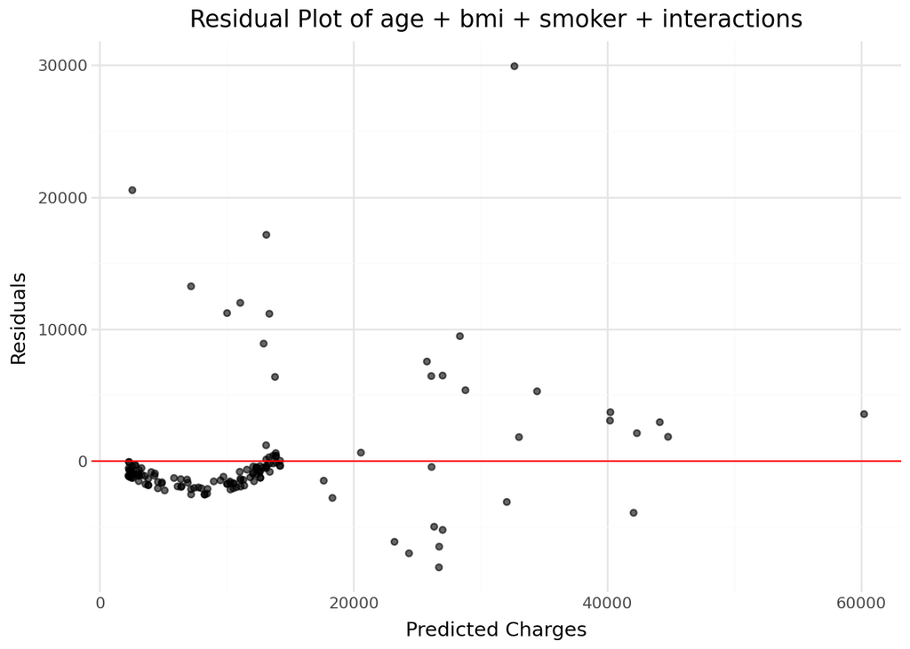

```python
# compute residuals on new data
plot_df = insurance_newdata.copy()
plot_df["pred_inter2"] = pred_inter2
plot_df["residuals"] = plot_df["charges"] - plot_df["pred_inter2"]

# plot residuals
(
    ggplot(plot_df, aes(x = "pred_inter2", y = "residuals"))
    + geom_point(alpha=0.6)
    + geom_hline(yintercept=0, color="red")
    + labs(
        title="Residual Plot of age + bmi + smoker + interactions",
        x="Predicted Charges",
        y="Residuals"
    )
    + theme_minimal()
)
```

# Part Five: Full Exploration

## Using any variables in this dataset, and any polynomial of those variables, find the model that best predicts on the new data after being fit on the original data.

## Make a plot showing the residuals of your final chosen model.

```python
# dummy variables for both the new and old insurance data
insurance_data["smoker_yes"] = (insurance_data["smoker"] == "yes").astype(int)
insurance_newdata["smoker_yes"] = (insurance_newdata["smoker"] == "yes").astype(int)

# response variable (target)
y_train = insurance_data["charges"]
y_test = insurance_newdata["charges"]
```

```python
# model for age, bmi, and someone who smokes
X_train_a_b_sm = insurance_data[["age", "bmi", "smoker_yes"]]
X_test_a_b_sm = insurance_newdata[["age", "bmi", "smoker_yes"]]

mdl_a_b_sm = LinearRegression()
mdl_a_b_sm.fit(
  X_train_a_b_sm,
  y_train
)

# predictions + calculating MSE
pred_1 = mdl_a_b_sm.predict(X_test_a_b_sm)
mse_a_b_sm1 = mean_squared_error(y_test, pred_1)

mse_a_b_sm1
# output: 35377541.24141632
```

```
35377541.24141632
```

```python
# squaring both age and bmi from the old and new datasets
insurance_data["age2"] = insurance_data["age"] ** 2
insurance_data["bmi2"] = insurance_data["bmi"] ** 2

insurance_newdata["age2"] = insurance_newdata["age"] ** 2
insurance_newdata["bmi2"] = insurance_newdata["bmi"] ** 2

X_train_quad2 = insurance_data[["age", "bmi", "smoker_yes", "age2", "bmi2"]]
X_test_quad2 = insurance_newdata[["age", "bmi", "smoker_yes", "age2", "bmi2"]]

mdl_quad2 = LinearRegression()
mdl_quad2.fit(
  X_train_quad2,
  y_train
)

pred_quad2 = mdl_quad2.predict(X_test_quad2)
mse_quad2 = mean_squared_error(y_test, pred_quad2)

mse_quad2
# output: 35327847.561730936
```

```
35327847.561730936
```

```python
# interaction terms for age and bmi, age and smoker, and bmi and smoker
# for both datasets
insurance_data["age_bmi"] = insurance_data["age"] * insurance_data["bmi"]
insurance_data["age_smoker"] = insurance_data["age"] * insurance_data["smoker_yes"]
insurance_data["bmi_smoker"] = insurance_data["bmi"] * insurance_data["smoker_yes"]

insurance_newdata["age_bmi"] = insurance_newdata["age"] * insurance_newdata["bmi"]
insurance_newdata["age_smoker"] = insurance_newdata["age"] * insurance_newdata["smoker_yes"]
insurance_newdata["bmi_smoker"] = insurance_newdata["bmi"] * insurance_newdata["smoker_yes"]

X_train_inter1 = insurance_data[["age", "bmi", "smoker_yes", "age_bmi", "age_smoker", "bmi_smoker"]]
X_test_inter1 = insurance_newdata[["age", "bmi", "smoker_yes", "age_bmi", "age_smoker", "bmi_smoker"]]

modl_inter1 = LinearRegression()
modl_inter1.fit(
  X_train_inter1,
  y_train
)

predict_inter1 = modl_inter1.predict(X_test_inter1)
mse_inter1 = mean_squared_error(y_test, predict_inter1)

mse_inter1
# output: 21785261.84690005
```

```
21785261.84690005
```

```python
# interaction terms with age^2 and bmi^2
# for both datasets
insurance_data["age2_smoker"] = insurance_data["age2"] * insurance_data["smoker_yes"]
insurance_data["bmi2_smoker"] = insurance_data["bmi2"] * insurance_data["smoker_yes"]

insurance_newdata["age2_smoker"] = insurance_newdata["age2"] * insurance_newdata["smoker_yes"]
insurance_newdata["bmi2_smoker"] = insurance_newdata["bmi2"] * insurance_newdata["smoker_yes"]


X_train_quad3 = insurance_data[[
    "age", "bmi", "smoker_yes",
    "age2", "bmi2",
    "age_bmi", "age_smoker", "bmi_smoker",
    "age2_smoker", "bmi2_smoker"
]]

X_test_quad3 = insurance_newdata[X_train_quad3.columns]

mdl_quad3 = LinearRegression()
mdl_quad3.fit(
  X_train_quad3,
  y_train
)

pred_quad3 = mdl_quad3.predict(X_test_quad3)
mse_quad3 = mean_squared_error(y_test, pred_quad3)

mse_quad3
# output: 21850366.6372263
```

```
21850366.6372263
```

```python
summary = pd.DataFrame({
    "Model": [
        "A: main effects",
        "B: quadratic",
        "C: interactions",
        "D: full quadratic + interactions"
    ],
    "MSE (new data)": [mse_a_b_sm1, mse_quad2, mse_inter1, mse_quad3]
})
summary
```

|  | Model | MSE (new data) |
| --- | --- | --- |
| 0 | A: main effects | 3.537754e+07 |
| 1 | B: quadratic | 3.532785e+07 |
| 2 | C: interactions | 2.178526e+07 |
| 3 | D: full quadratic + interactions | 2.185037e+07 |

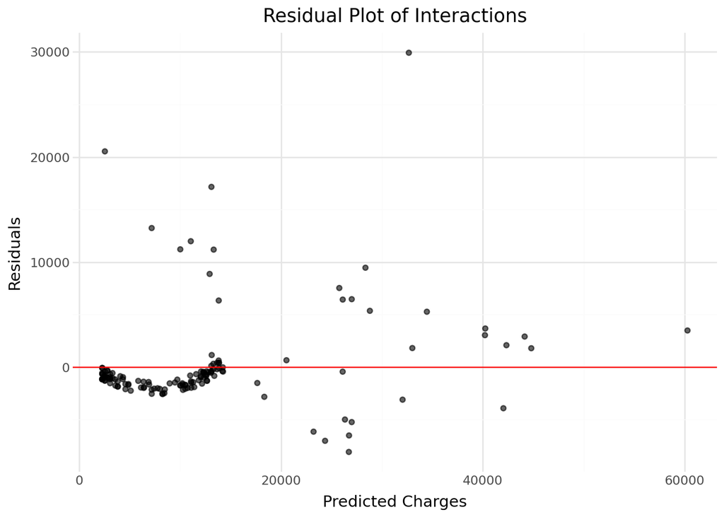

```python
plot_df = insurance_newdata.copy()
plot_df["predicted"] = predict_inter1
plot_df["residuals"] = plot_df["charges"] - plot_df["predicted"]

(
    ggplot(plot_df, aes("predicted", "residuals"))
    + geom_point(alpha=0.6)
    + geom_hline(yintercept=0, color="red")
    + labs(
        title="Residual Plot of Interactions",
        x="Predicted Charges",
        y="Residuals"
    )
    + theme_minimal()
)
```